# GLM for Data With Non-Normal Distributions: Counts

Hector 2015 Chapter 9; Beckerman 2017 Chapter 7; Crawley 2007 R Book

Good background video:

https://www.youtube.com/watch?v=i62gffPrZYA

Count data resemble binomial count data in taking whole number values, but differ in that we only know how many times an event occurred, not the number of times it did not occur.

The starting point for GLM analysis of count data is using the **Poisson distribution** and a **log link function**. The log link function (or rather its inverse) ensures that all predicted counts are positive (we can’t have a negative count!) by taking the *exponent of the values generated by the linear predictor*.

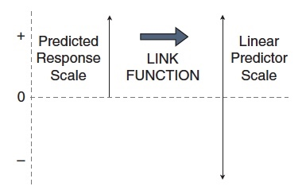

The Poisson distribution defines the variance as equal to the mean, but as always this assumption needs to be examined since count data won’t necessarily have this property in all cases.

The Poisson distribution has only one parameter, called λ.

- The mean of a Poisson distribution is λ.
- The variance of a Poisson distribution is also λ.

In most distributions, the mean is represented by µ (mu) and the variance is represented by σ² (sigma squared). Because these two parameters are the same in a Poisson distribution, we use the λ symbol to represent both.

If X ∼ Po(λ), then

μ = λ

σ = √λ

σ² = λ

**If this assumption is met the ratio of residual deviance to residual DF (the dispersion) should be approximately 1:1.**

What does a Poisson Distribution look like? It depends a lot on the mean. As λ increases, the distribution looks more and more similar to a normal distribution. In fact, when λ is 10 or greater, a normal distribution is a good approximation of the Poisson distribution.

```r
#generate fake poisson distributions using 1000 replicate draws with differing means
set.seed(1234) #so everybodys 'random draws' look the same
data <- data.frame(cond = factor(rep(c("A","B","C","D"), each=1000)),
                   rating = c(rpois(1000, 0.8),
                              rpois(1000, 1.5),
                              rpois(1000, 5.0),
                              rpois(1000, 12.0)))

#find the mean of each group
means <- data %>%
  group_by(cond) %>%
  summarize(mean_rating = mean(rating, na.rm=TRUE))
means
```

```
## # A tibble: 4 × 2
##   cond  mean_rating
##   <fct>       <dbl>
## 1 A           0.825
## 2 B           1.42
## 3 C           5.09
## 4 D          12.0
```

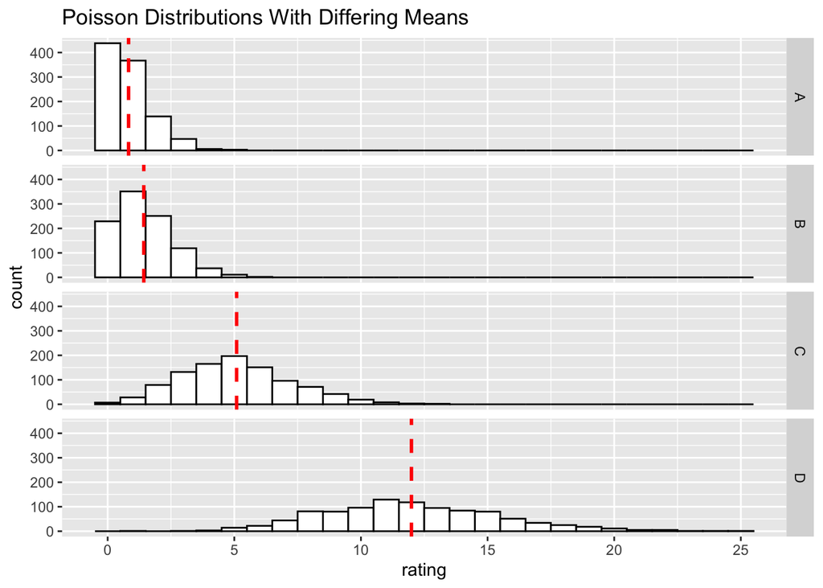

[figure not shown]

```r
# Plot histograms with mean lines, using means from above
ggplot(data, aes(x=rating)) +
  geom_histogram(binwidth=1, colour="black", fill="white") +
  facet_grid(cond ~ .) +
  scale_x_continuous(breaks=seq(0,30,5)) +
  ggtitle("Poisson Distributions With Differing Means") +
  geom_vline(data=means, aes(xintercept=mean_rating), linetype="dashed", linewidth=1, colour="red")
```

**Example from Crawley (2007). The R Book.**

Straightforward linear regression methods (assuming constant variance, normal errors) are not appropriate for count data for four main reasons:

- The linear model might lead to the prediction of negative counts.
- The variance of the response variable is likely to increase with the mean.
- The errors will not be normally distributed.
- Zeros are difficult to handle in transformations.

In R, count data are handled very elegantly in a generalized linear model by specifying family=poisson which sets errors = Poisson and link = log (see p. 515). The log link ensures that all the fitted values are positive, while the Poisson errors take account of the fact that the data are integer and have variances that are equal to their means.

```r
clusters <- read.csv("../data/clusters.csv")
```

Does the incidence of cancer (number of cases) increase with distance to a nuclear reactor?

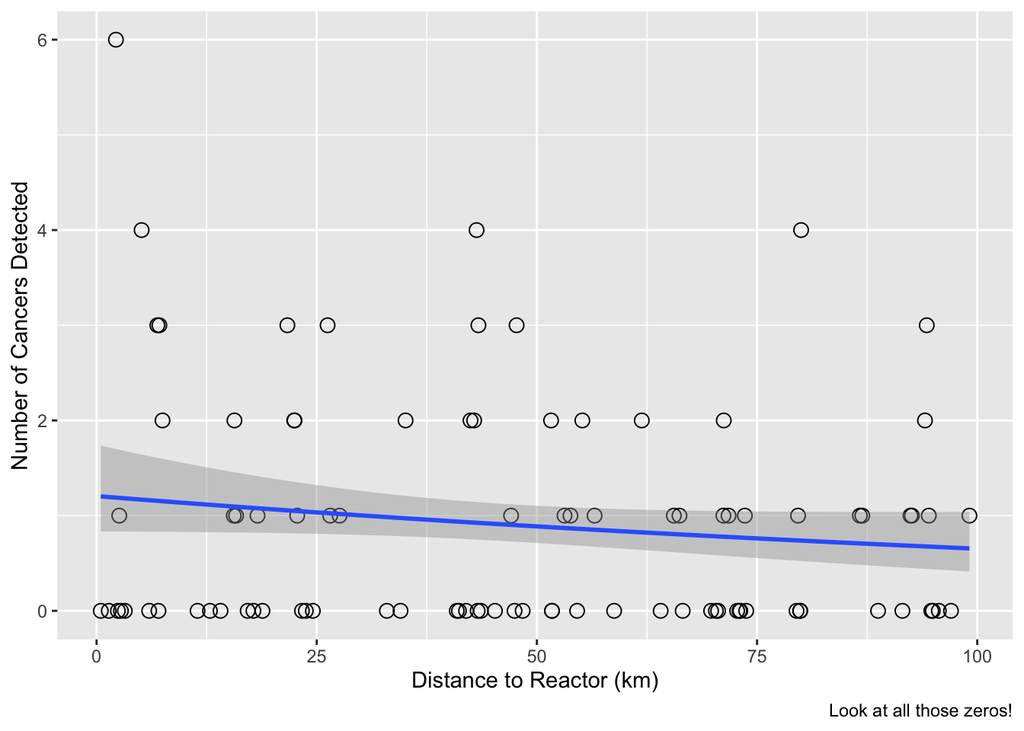

```r
ggplot(clusters, aes(distance, cancers)) +
  geom_point(size=3, pch = 21) +
  geom_smooth(method="glm", method.args=list(family="poisson"(link="log"))) +
  ylab("Number of Cancers Detected") +
  xlab("Distance to Reactor (km)") +
  labs(caption = "Look at all those zeros!")
```

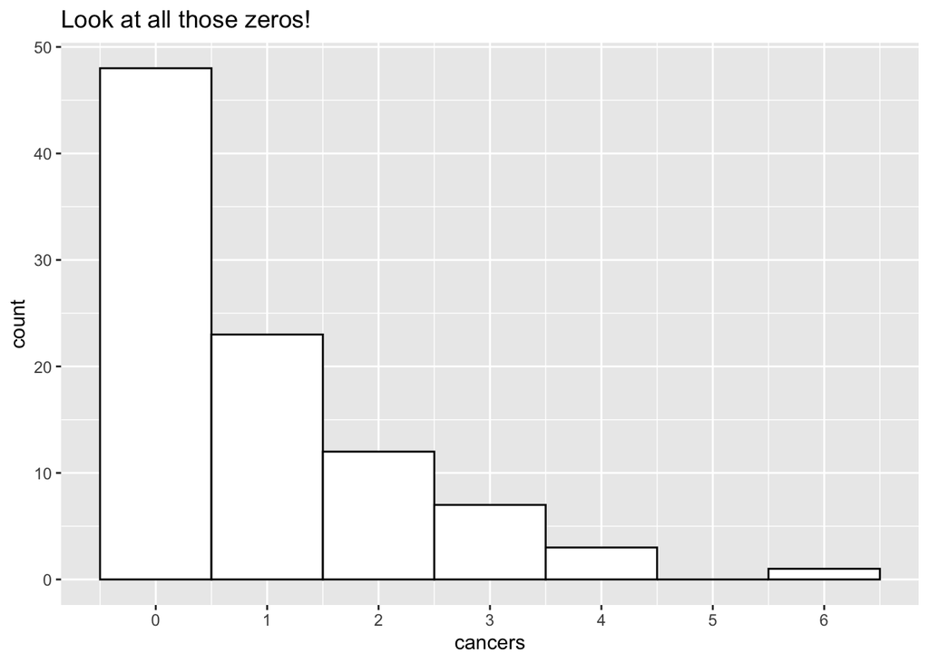

```r
ggplot(data=clusters, aes(cancers)) +
  geom_histogram(binwidth=1, colour="black", fill="white") +
  scale_x_continuous(breaks=seq(0,6,1)) +
  labs(title = "Look at all those zeros!")
```

```r
model_cancer_poisson <- glm(cancers ~ distance, family = poisson, data=clusters)
summary(model_cancer_poisson)
```

```
##
## Call:
## glm(formula = cancers ~ distance, family = poisson, data = clusters)
##
## Coefficients:
##              Estimate Std. Error z value Pr(>|z|)
## (Intercept)  0.186865   0.188728   0.990   0.3221
## distance    -0.006138   0.003667  -1.674   0.0941 .
## ---
## Signif. codes:  0 '***' 0.001 '**' 0.01 '*' 0.05 '.' 0.1 ' ' 1
##
## (Dispersion parameter for poisson family taken to be 1)
##
##     Null deviance: 149.48  on 93  degrees of freedom
## Residual deviance: 146.64  on 92  degrees of freedom
## AIC: 262.41
##
## Number of Fisher Scoring iterations: 5
```

The trend does not look to be significant, but **look at the residual deviance**. It is assumed that this is the same as the residual degrees of freedom. The fact that residual deviance is larger than residual df indicates that we likely have overdispersion (data are more spread out than the model expects based on the poisson distribution).

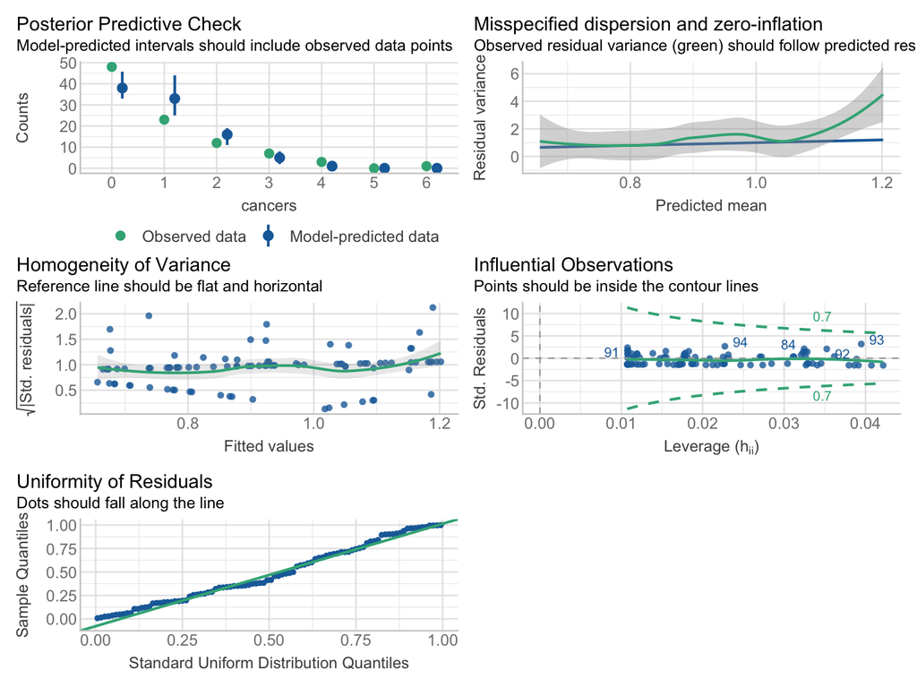

```r
check_model(model_cancer_poisson)
```

We can compensate for the overdispersion by refining the model using quasi-Poisson rather than Poisson errors. Quasi-Poisson is specifically designed to handle overdispersion, which is common in count data.

```r
model_cancer_quasi <- glm(cancers~distance, family = quasipoisson, data = clusters)
summary(model_cancer_quasi)
```

```
##
## Call:
## glm(formula = cancers ~ distance, family = quasipoisson, data = clusters)
##
## Coefficients:
##              Estimate Std. Error t value Pr(>|t|)
## (Intercept)  0.186865   0.235364   0.794    0.429
## distance    -0.006138   0.004573  -1.342    0.183
##
## (Dispersion parameter for quasipoisson family taken to be 1.555271)
##
##     Null deviance: 149.48  on 93  degrees of freedom
## Residual deviance: 146.64  on 92  degrees of freedom
## AIC: NA
##
## Number of Fisher Scoring iterations: 5
```

Compensating for the overdispersion (using quasipoisson) increased to P-value from 0.094 to 0.183, so there is no compelling evidence to support the idea that cancer incidence is related to distance from the reactor. Therefore it doesn’t make much sense to try to interpret the distance slope coefficient.

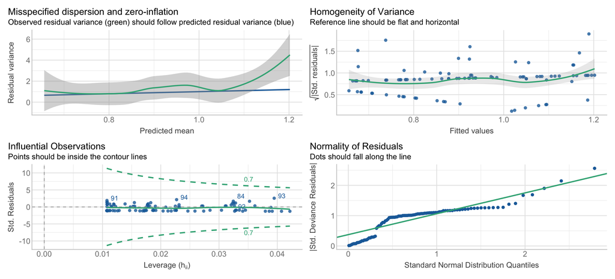

```r
check_model(model_cancer_quasi)
```

Quasipoisson fit looks the same as the Poisson model; not much else we can do.  
**Lets look at and example from the literature: Hautier, Niklaus, and Hector (2009; Science, 324: 636).** https://www.zora.uzh.ch/id/eprint/18666/2/Hautier_2009.pdf

- Counts of the number of species in experimental grassland plots exposed to fertilization and addition of light to the grassland understory.
- Fertilization usually increases productivity but leads to a loss of plant diversity.
- One idea is that this is because enhanced growth leads to increasingly asymmetric competition for light (taller plants not only use the light themselves but can reduce its passage to their shorter competitors).
- The experiment tested this hypothesis by restoring light levels in the grassland understory: if the idea is correct, this should prevent and reduce loss of species.

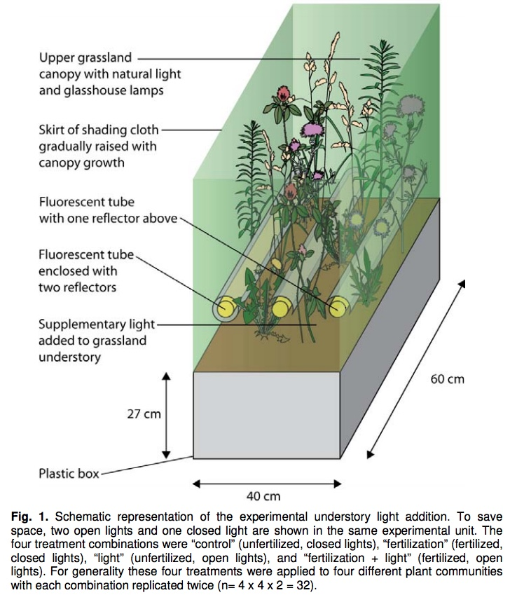

```r
Fertilizer_counts <- read.csv("../data/fertilizer_counts.csv")
#View(Fertilizer_counts)
```

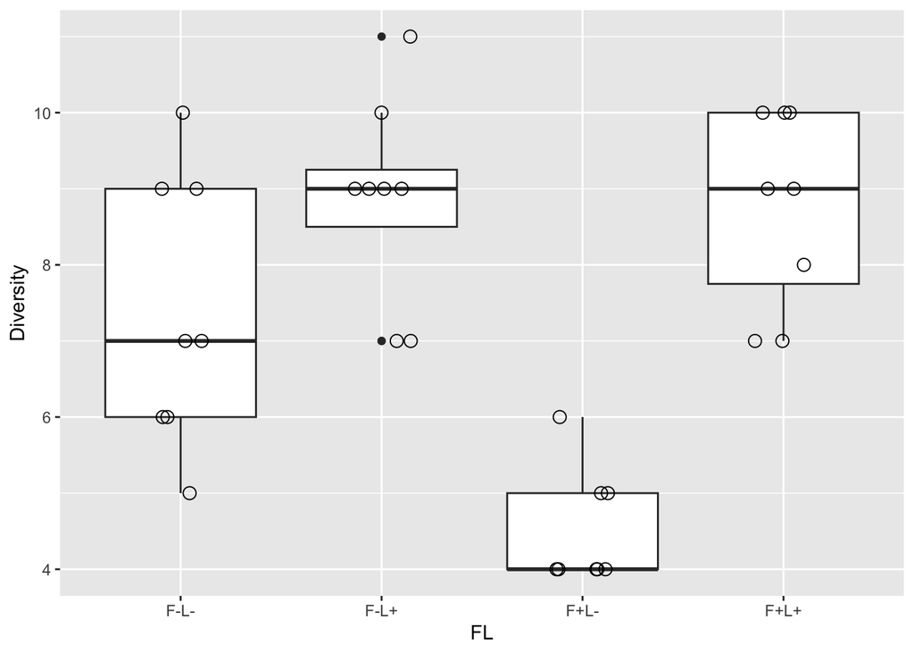

```r
ggplot(Fertilizer_counts, aes(FL,Diversity)) +
  geom_boxplot() +
  geom_jitter(shape=1, size=3, height = 0, width = .15) #because count data overlap a lot when duplicate values are present
```

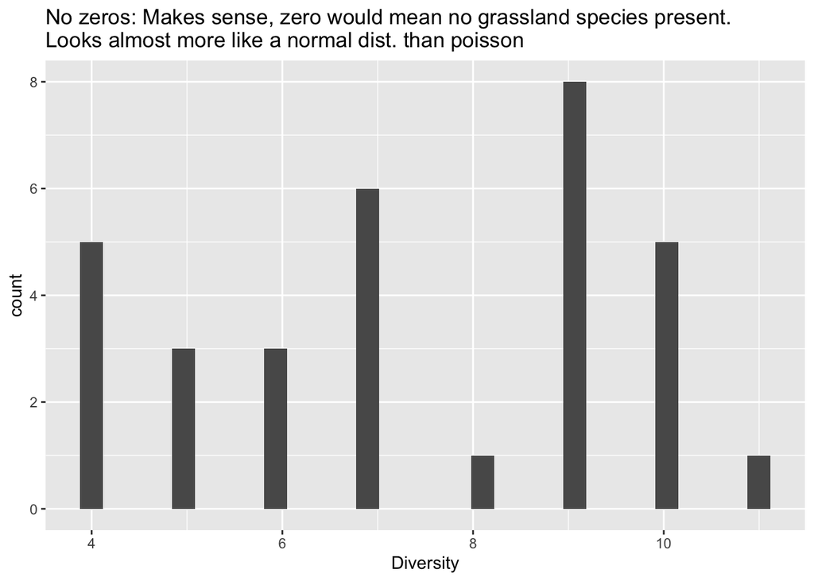

```r
ggplot(data=Fertilizer_counts, aes(Diversity)) +
  geom_histogram() +
  labs(title = "No zeros: Makes sense, zero would mean no grassland species present. \nLooks almost more like a normal dist. than poisson")
```

```r
pois1 <- glm(Diversity~Light*Fertilizer, family= poisson(link=log), data= Fertilizer_counts)
```

```r
summary(pois1)
```

```
##
## Call:
## glm(formula = Diversity ~ Light * Fertilizer, family = poisson(link = log),
##     data = Fertilizer_counts)
##
## Coefficients:
##                      Estimate Std. Error z value Pr(>|z|)
## (Intercept)            1.9981     0.1302  15.348   <2e-16 ***
## LightL+                0.1851     0.1762   1.051   0.2933
## FertilizerF+          -0.4940     0.2115  -2.336   0.0195 *
## LightL+:FertilizerF+   0.4798     0.2704   1.775   0.0759 .
## ---
## Signif. codes:  0 '***' 0.001 '**' 0.01 '*' 0.05 '.' 0.1 ' ' 1
##
## (Dispersion parameter for poisson family taken to be 1)
##
##     Null deviance: 21.2770  on 31  degrees of freedom
## Residual deviance:  6.6221  on 28  degrees of freedom
## AIC: 136.61
##
## Number of Fisher Scoring iterations: 4
```

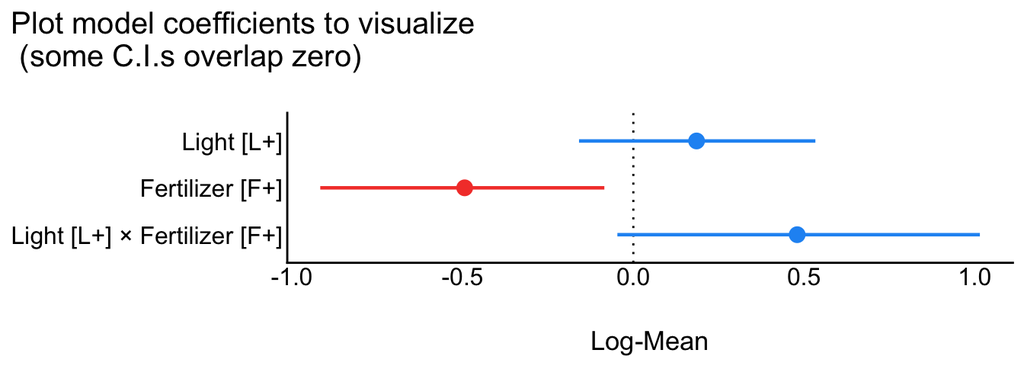

```r
#easystats package
plot(parameters(pois1)) +
  ggplot2::labs(title = "Plot model coefficients to visualize\n (some C.I.s overlap zero)")
```

Count data are often overdispersed where the residual deviance is more than expected, but in this case it is much less than expected (underdispersion: Residual deviance: 6.6221 on 28 degrees of freedom).

Minor levels of underdispersion are often ignored, but here we could again use *quasi-maximum* likelihood to take it into account by estimating the observed level of variation and adjusting the standard errors accordingly. (note: notice how the standard errors are recalculated [but coefficients are not], but that also changes the calculated test statistic, z or t, [which is ratio of estimate to error] and the P-value)

```r
qpois1 <- glm(Diversity~Light*Fertilizer, quasipoisson, data= Fertilizer_counts)
summary(qpois1)
```

```
##
## Call:
## glm(formula = Diversity ~ Light * Fertilizer, family = quasipoisson,
##     data = Fertilizer_counts)
##
## Coefficients:
##                      Estimate Std. Error t value Pr(>|t|)
## (Intercept)           1.99810    0.06330  31.564  < 2e-16 ***
## LightL+               0.18514    0.08566   2.161  0.03936 *
## FertilizerF+         -0.49402    0.10283  -4.804 4.74e-05 ***
## LightL+:FertilizerF+  0.47983    0.13146   3.650  0.00106 **
## ---
## Signif. codes:  0 '***' 0.001 '**' 0.01 '*' 0.05 '.' 0.1 ' ' 1
##
## (Dispersion parameter for quasipoisson family taken to be 0.2364279)
##
##     Null deviance: 21.2770  on 31  degrees of freedom
## Residual deviance:  6.6221  on 28  degrees of freedom
## AIC: NA
##
## Number of Fisher Scoring iterations: 4
```

```r
kableExtra::kable(round(coef(qpois1), 3), caption = "Poisson Regression Coefficients")
```

Poisson Regression Coefficients

|  | x |
| --- | --- |
| (Intercept) | 1.998 |
| LightL+ | 0.185 |
| FertilizerF+ | -0.494 |
| LightL+:FertilizerF+ | 0.480 |

```r
confint(qpois1)
```

```
##                            2.5 %     97.5 %
## (Intercept)           1.87140250  2.1196490
## LightL+               0.01759189  0.3535623
## FertilizerF+         -0.69738611 -0.2939376
## LightL+:FertilizerF+  0.22305770  0.7385982
```

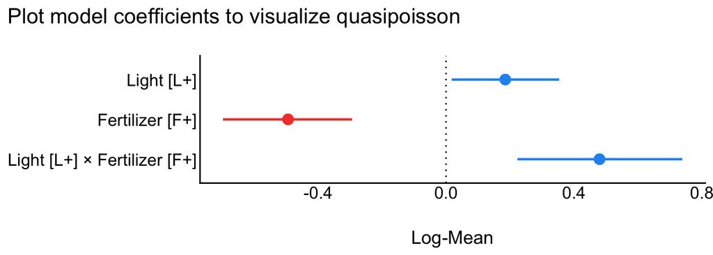

```r
#easystats package
plot(parameters(qpois1)) +
  ggplot2::labs(title = "Plot model coefficients to visualize quasipoisson")
```

Interpretation (remember that coefficients are still on the log scale):

As usual we start at the bottom of the table with the interaction. The interaction is significant so we have our main result; the significance of the other rows is of limited interest (they give the average effects and the interaction tells us that average effects can be misleading because the effects of the factors depend on each other).

On average, fertilizer leads to a loss of species but when light is added to the understorey this effect is cancelled out (adding light has a positive effect here, although this effect was not significant in the original analysis of changes in species richness which had the advantage of controlling for initial variation in diversity between plots which our analysis here does not do).

The `interaction.plot()` function provides a quick option for examining interactions:

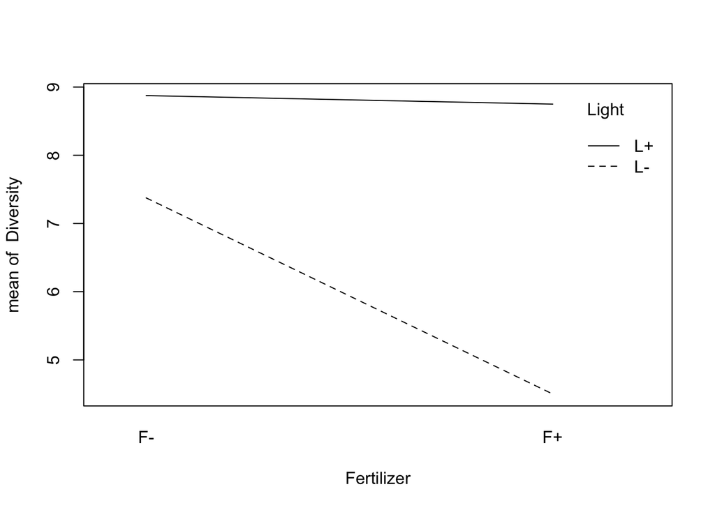

```r
attach(Fertilizer_counts)
interaction.plot(Fertilizer, Light, Diversity)
```

```r
detach(Fertilizer_counts)
```

While the data here are integer counts, the Poisson distribution does not provide a very good model for the variation, which is less than expected (count data often have more low values and include zeros). More often, Poisson GLMs are overdispersed (quasi-Poisson models are an option for taking the overdispersion into account).

It is possible that the Poisson distribution may be close to normally distributed here so we could try a Gaussian GLM (although it could predict negative counts which are impossible with the Poisson model).

The `boxcox()` function can guide us on transformations:

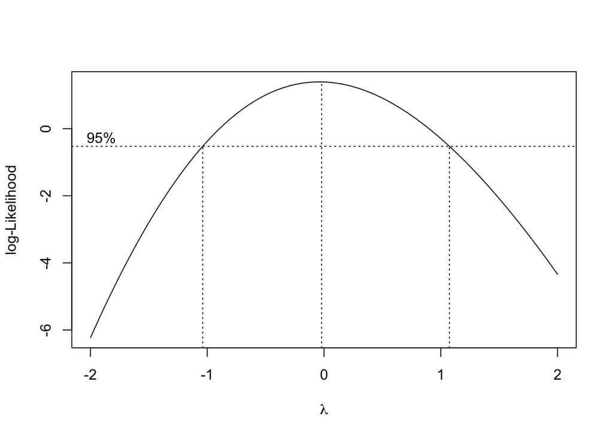

```r
boxcox(glm(Diversity~Light*Fertilizer, data = Fertilizer_counts))
```

The CI is quite wide and includes no action (λ = 1), but the ‘best’ transformation is the log (λ = 0):

```r
log.norm <- glm(Diversity~Light*Fertilizer, gaussian (link=log), data= Fertilizer_counts)
```

If you extract the coefficients you will find that, perhaps not surprisingly (the only difference is the variance function), the estimated coefficients are very similar to the quasi-Poisson GLM (not shown), confirming that a Gaussian GLM (or a normal least squares analysis of the log-transformed data) produces essentially the same result.

```r
summary(log.norm)
```

```
##
## Call:
## glm(formula = Diversity ~ Light * Fertilizer, family = gaussian(link = log),
##     data = Fertilizer_counts)
##
## Coefficients:
##                      Estimate Std. Error t value Pr(>|t|)
## (Intercept)           1.99810    0.06422  31.113  < 2e-16 ***
## LightL+               0.18514    0.08350   2.217 0.034898 *
## FertilizerF+         -0.49402    0.12330  -4.007 0.000413 ***
## LightL+:FertilizerF+  0.47983    0.14485   3.313 0.002556 **
## ---
## Signif. codes:  0 '***' 0.001 '**' 0.01 '*' 0.05 '.' 0.1 ' ' 1
##
## (Dispersion parameter for gaussian family taken to be 1.794648)
##
##     Null deviance: 149.50  on 31  degrees of freedom
## Residual deviance:  50.25  on 28  degrees of freedom
## AIC: 115.25
##
## Number of Fisher Scoring iterations: 4
```

```r
coef(log.norm)
```

```
##          (Intercept)              LightL+         FertilizerF+
##            1.9980959            0.1851424           -0.4940185
## LightL+:FertilizerF+
##            0.4798339
```

**Another Example: Soay Sheep**